# Иллюстрации к статье

Вадим Хайтов

12 марта 2019 г

## Рисунок с датами ключевых событий

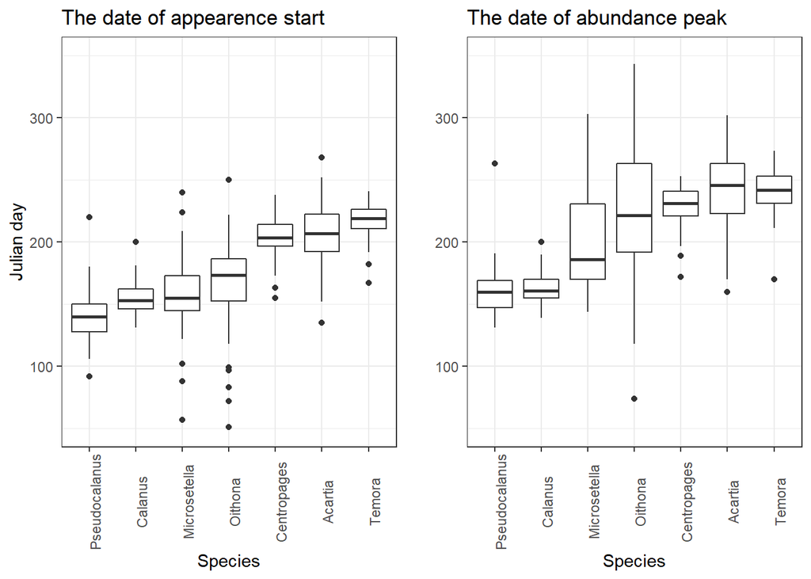

## Многолетние изменения фенологических показателей.

Мне кажется, чтобы не загромождать статью, для демонстрации смешения фенологии лучше выбрать какой-то один фенологический показатель (начало или дату пика). Далее рисунки и парамтеры моделей давть для него.

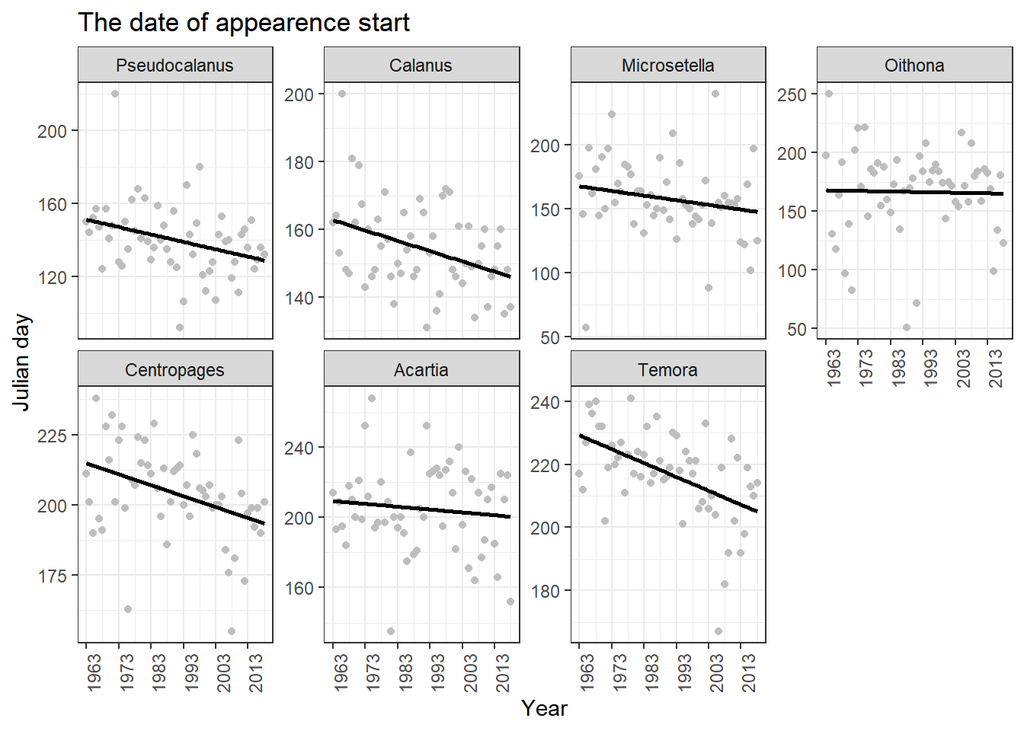

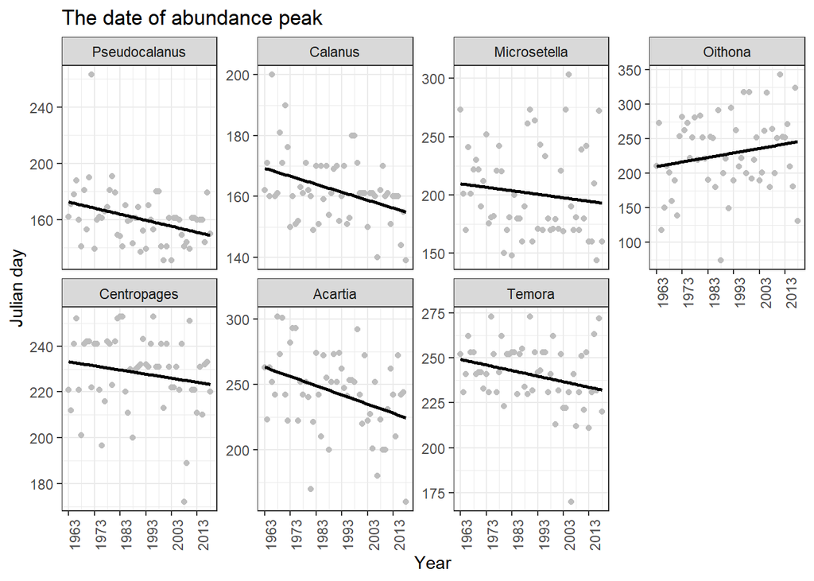

Угловые коэффициенты линейных моделей, описывающих изменение даты ключевых событий.

**Важно!** Оценка достоверости происходит с помощью теста Матела. Но! Для этого анализза берется не каждый отдельно фенологический показатель, а полная фенологическая матрица, которая сравнивается с градиентной модельной атрицей. То есть, дается оценка статистической значимости наличия тренда во всей матрице. Так, по-моему, корректнее, хотя и сложно для объясненния.

Slope terms of linear models fitted and Mantel test p-value for comaprison of phenologiacal matrix of each species with gradient model-matrix

| Species | Slope_Begin | Slope_Peak | Slope_Meadle | Slope_End | Mantel_p |
| --- | --- | --- | --- | --- | --- |
| Pseudocalanus | -0.41 | -0.43 | -0.54 | -0.67 | 0.1075 |
| Calanus | -0.30 | -0.26 | -0.29 | -0.27 | 0.0082 |
| Microsetella | -0.36 | -0.30 | -0.35 | -0.35 | 0.1488 |
| Oithona | -0.05 | 0.65 | 0.00 | 0.01 | 0.0831 |
| Centropages | -0.39 | -0.18 | -0.28 | -0.17 | 0.0484 |
| Acartia | -0.16 | -0.70 | -0.35 | -0.52 | 0.0383 |
| Temora | -0.44 | -0.31 | -0.33 | -0.23 | 0.0020 |

## Факторы, определяющие сдвиги в фенологии сообщества копепод

### Результаты ССА

Полученная модель (при учете всех канонических корреспондентных осей) объясняет 20.7% суммарной изменчивости. При этом на первую и вторую оси приходится 11.5 и 4.1% соответственно (то есть приведенная на рисунке ординация отражает 15.6% общей изменчивости.

### Оценка значимости модели

Permutation significance test of the CCA model

| term | df | ChiSquare | statistic | p.value |
| --- | --- | --- | --- | --- |
| Model | 5 | 0.0027154 | 2.611038 | 1e-04 |
| Residual | 50 | 0.0103996 |  |  |

[output not shown]

Permutation significance test of each terms included in the CCA model

| term | df | ChiSquare | statistic | p.value |
| --- | --- | --- | --- | --- |
| t_3 | 1 | 0.0005095 | 2.449547 | 0.0175 |
| Su_start | 1 | 0.0003999 | 1.922827 | 0.0619 |
| Su_end_1 | 1 | 0.0005305 | 2.550600 | 0.0152 |
| Acartia_N | 1 | 0.0004070 | 1.956810 | 0.0596 |
| Microsetella_N | 1 | 0.0010090 | 4.851220 | 0.0001 |
| Residual | 50 | 0.0103996 |  |  |

### Картинка, визуализирующая модель ССА

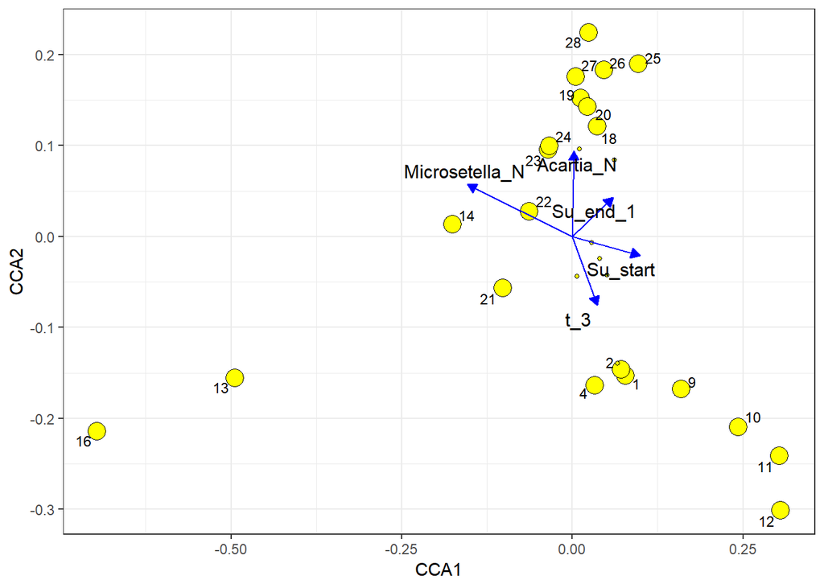

Обозначения фенологических характеристик приведены в следующей таблице.

| Phenological Event | Label | Phenological Event | Label |
| --- | --- | --- | --- |
| Pseudocalanus_Begin | 1 | Acartia_Meadle | 22 |
| Pseudocalanus_Meadle | 2 | Acartia_End | 23 |
| Pseudocalanus_Peak | 4 | Acartia_Peak | 24 |
| Microsetella_Begin | 9 | Temora_Begin | 25 |
| Microsetella_Meadle | 10 | Temora_Meadle | 26 |
| Microsetella_End | 11 | Temora_End | 27 |
| Microsetella_Peak | 12 | Temora_Peak | 28 |
| Oithona_Begin | 13 |  |  |
| Oithona_Meadle | 14 |  |  |
| Oithona_Peak | 16 |  |  |
| Centropages_Meadle | 18 |  |  |
| Centropages_End | 19 |  |  |
| Centropages_Peak | 20 |  |  |
| Acartia_Begin | 21 |  |  |

## Мнолетние изенения факторов, значимых для фенологии

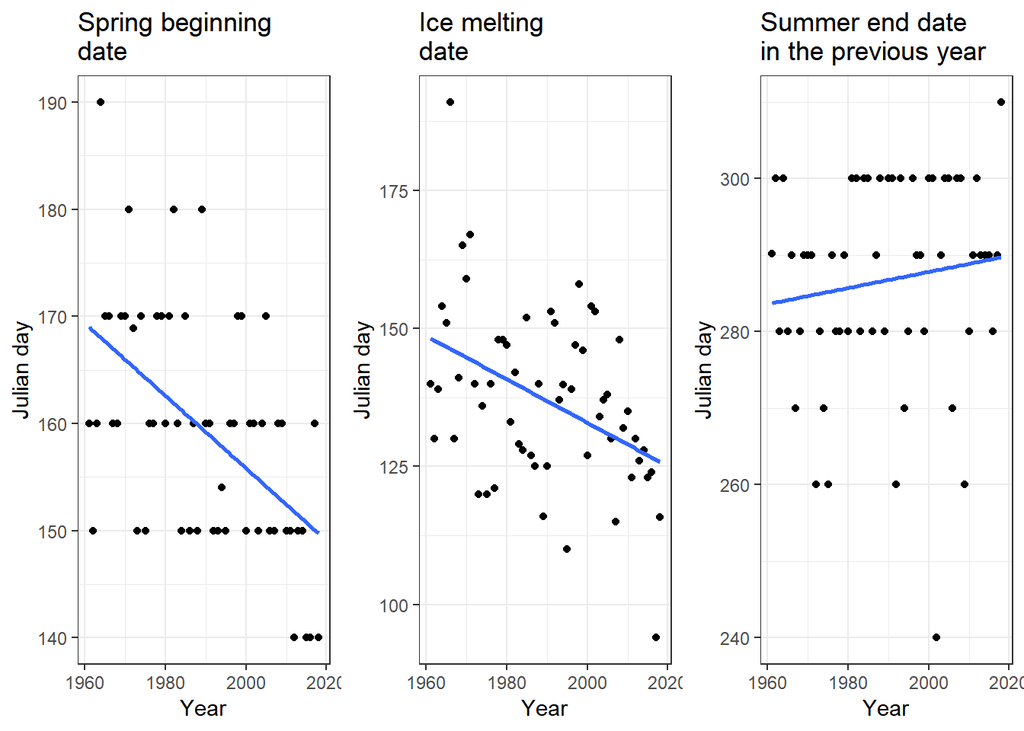

## Многолетняя динамика обилия видов

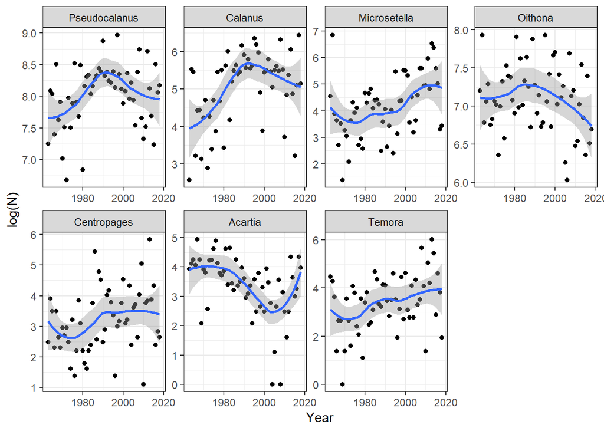

## Зависимость обилия видов от параметров среды

Здесь надо подумать. Может быть надо менно с этого начать. Этот результат показывает, что обилие видов, как таковое, находится в зависимости от климатических факторов. НО! Это не совсем то, что хотелось, как я понимаю (хотелось выявить, как обилие связано с фенологическими сдвигами). Как показать именно то, что хотелось, пока не понял. Еще думаю.

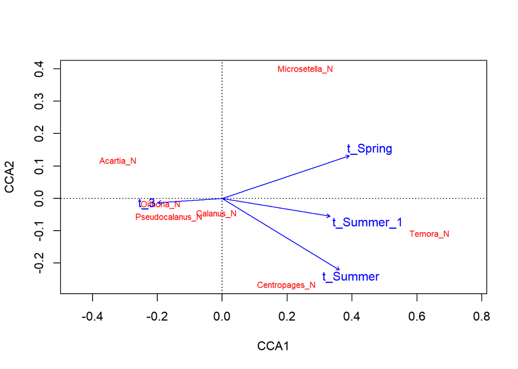

## Связь обилия и фенологических показателей

В качестве фенологического показателя взята дата начала

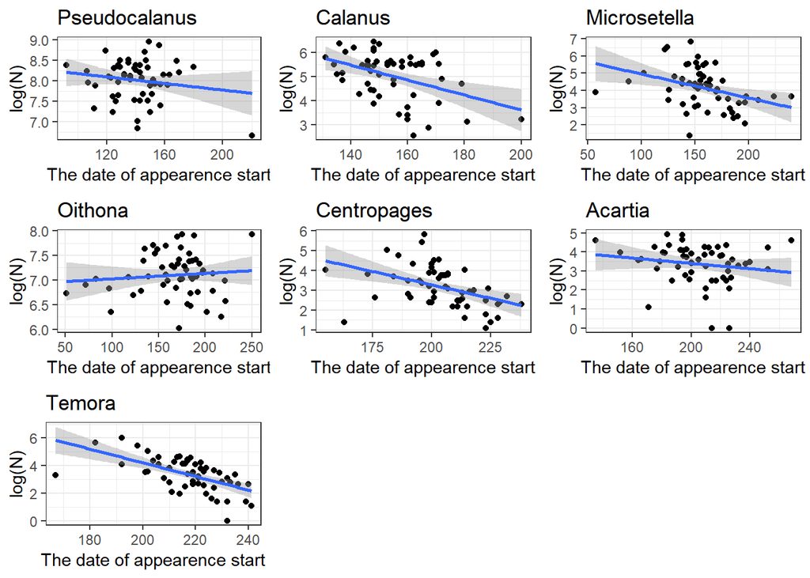